# Biogeography

Dean Adams (dcadams@iastate.edu)

2026-03-06

### **Overview**

Today we will explore how to perform a biogeography analysis in a phylogenetic framework. We learned about two models: DEC (dispersal-exctinction-cladogenesis) and DEC+J (dispersal-extinction-cladogenesis plus jumps). **NOTE: much of this tutorial follows the Supplemental tutorial from Chapter 11 in Revell and Harmon (Phylogenetic Comparative Methods in R).**

To implement these models, we require the package `BioGeoBEARS`. This is not on CRAN, so we must install from Github:

```r
devtools::install_github('nmatzke/BioGeoBEARS')
```

### Download data files

Today we will use data from the following files:

[Phylogeny](https://github.com/deanadams/MacroevolutionPracticals/blob/main/14-Biogeography/data/attine-tree-pruned.tre)

[Data](https://github.com/deanadams/MacroevolutionPracticals/blob/main/14-Biogeography/data/attine-distribution-data.txt)

Additionally, The R-script for running the code found in this tutorial is found here:

[RScript](https://github.com/deanadams/MacroevolutionPracticals/blob/main/14-Biogeography/scripts/Biogeography.r)

As before, on your local computer, place them in a folder named ‘TutorialData’, which is found in the same directory as this tutorial.

### **Reading Data**

First we will load libraries and read in the data. Today we will be examining data from Branstetter et al. (2017). These are data for fungus-farming ant species, whose biogeographic distributions are described as presence/absence in 5 geographic regions around the world. Our aim is to hypothesize the ancestral origin of this group.

```r
library(phytools)
library(BioGeoBEARS)
ant.tree <- read.tree("../data/attine-tree-pruned.tre")
print(ant.tree, prinlen = 2)
```

```
##
## Phylogenetic tree with 84 tips and 83 internal nodes.
##
## Tip labels:
##   Acanthognathus_ocellatus_1492, Daceton_armigerum_1448, Lenomyrmex_foveolatus_1500, Microdaceton_ug01_1574, Orectognathus_versicolor_1564, Colobostruma_biconvexa_1576, ...
##
## Rooted; includes branch length(s).
```

```r
writeLines(readLines("../data/attine-distribution-data.txt",4))
```

```
## 84   5 (A B C D E)
## Acanthognathus_ocellatus_1492    01100
## Acromyrmex_echinatior_Genome 01000
## Acromyrmex_balzani_1487  00100
```

```r
ant.data <- getranges_from_LagrangePHYLIP(lgdata_fn =
                "../data/attine-distribution-data.txt")
```

We see that our data consist of 84 species, found in one or more biogeographic regions (five regions total).

### **Plotting the data**

As always, it is useful to plot the data. Here let’s plot the biogeographic regions on the phylogeny:

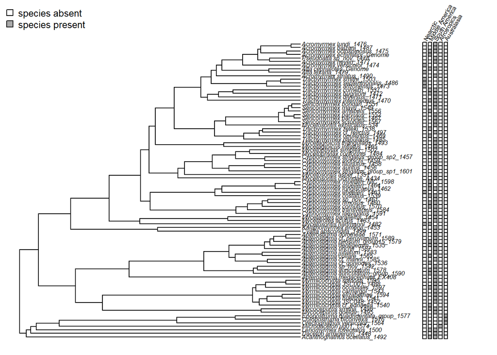

```r
tmp <- ant.data@df
tmp[,1:5] <- lapply(tmp[,1:5], factor)
colnames(tmp) <- c("Nearctic","Middle America",
                   "South America", "Afrotropics",
                   "Australasia")
colors <- setNames(replicate(ncol(tmp),
              setNames(c("white", "darkgray"),0:1),
              simplify = FALSE), colnames(tmp))
object <- plotTree.datamatrix(ant.tree,tmp,fsize=0.5,
            yexp=1.1, header=TRUE, xexp=1.25,colors = colors)
legend("topleft", c("species absent","species present"),
       pch=22, pt.bg=c("white","darkgray"), pt.cex=1.3,cex=0.8,bty="n")
```

Notice that all species are geographically-restricted to one or two regions of the globe.

### **DEC Analysis**

Now let’s run a DEC analysis, where we describe biogeographic shifts across the phylogeny in terms of dispersal, extinction, and cladogenesis. One quirk with `BioGeoBEARS` is that unlike most `R`-packages where data are loaded into the `R` environment, This package reads directly from data files. So the input looks a bit different from what we’ve seen in earlier tutorials. Notice that on your computer, `BioGeoBEARS` spits out considerable output during the analysis. For ease of presentation that has been suppressed in this tutorial.

```r
max_range_size <- 2
bgb_run <- define_BioGeoBEARS_run(
  num_cores_to_use = 1,
  max_range_size = max_range_size,
  trfn = "../data/attine-tree-pruned.tre",
  return_condlikes_table = TRUE)
bgb_run$geogfn <- "../data/attine-distribution-data.txt"
check_BioGeoBEARS_run(bgb_run)
DEC.fit <- bears_optim_run(bgb_run)
DEC.fit$optim_result
```

```
##                 p1          p2     value fevals gevals niter convcode  kkt1
## bobyqa 0.006267913 0.001789498 -143.0313     38     NA    NA        0 FALSE
##        kkt2 xtime
## bobyqa TRUE  0.53
```

Here is the optimized output:

- p1 = the disperal rate
- p2 = local extinction rate
- value = logL

Now let’s plot the results graphically:

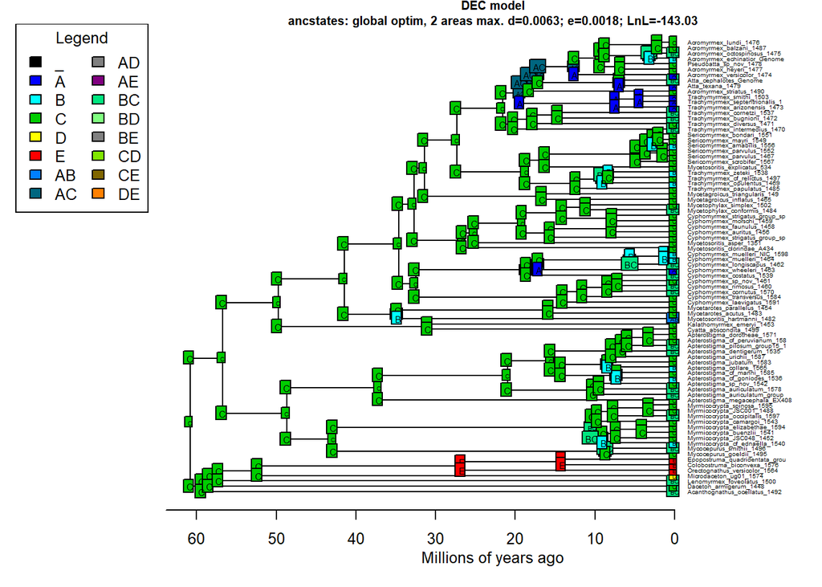

```
##         LnL nparams           d           e
## 1 -143.0313       2 0.006267913 0.001789498
```

```r
layout(matrix(1:2, 1,2), widths=c(0.2,0.8))
par(mar=c(4.1,0.1,1.3,0.1),cex=0.8)
plot_BioGeoBEARS_results(DEC.fit,
    analysis_titletxt = "DEC model",
    plotlegend = TRUE, tipcex = 0.4,statecex = 0.4)
```

This shows us that Region C (South America) is the most likely ancestral area for the group.

### **DEC+J Analysis**

Now let’s consider the DEC+J model. This includes dispersal, extinction, cladogenesis, and jump-speciation (where a lineage disperses to a new location and simultaneously speciates).

To implement the model, let’s use our DEC parameters as the starting point for DEC+J:

```r
dstart <- DEC.fit$outputs@params_table["d","est"]
estart <- DEC.fit$outputs@params_table["e","est"]
jstart <- 0.0001

bgb_run$BioGeoBEARS_model_object@params_table["d",
        "init"] <- dstart
bgb_run$BioGeoBEARS_model_object@params_table["d",
        "est"] <- dstart
bgb_run$BioGeoBEARS_model_object@params_table["e",
        "init"] <- estart
bgb_run$BioGeoBEARS_model_object@params_table["e",
        "est"] <- estart
bgb_run$BioGeoBEARS_model_object@params_table["j",
        "type"] <- "free"
bgb_run$BioGeoBEARS_model_object@params_table["j",
        "init"] <- jstart
bgb_run$BioGeoBEARS_model_object@params_table["j",
        "est"] <- jstart
check_BioGeoBEARS_run(bgb_run)
DEC_J.fit <- bears_optim_run(bgb_run)
DEC_J.fit$optim_result
```

```
##                 p1    p2         p3     value fevals gevals niter convcode
## bobyqa 0.004046294 1e-12 0.02133334 -136.0288     61     NA    NA        0
##         kkt1 kkt2 xtime
## bobyqa FALSE TRUE     1
```

Here is the optimized output. As before, p1 = the disperal rate, p2 = local extinction rate, and now p3 = the jump speciation rate.

Now let’s plot the results graphically:

```
##
## NOTE: multiple states tied
##
## Note: in get_ML_probs(), picking the first state in the tie; use unlist_TF=FALSE to see all states.
```

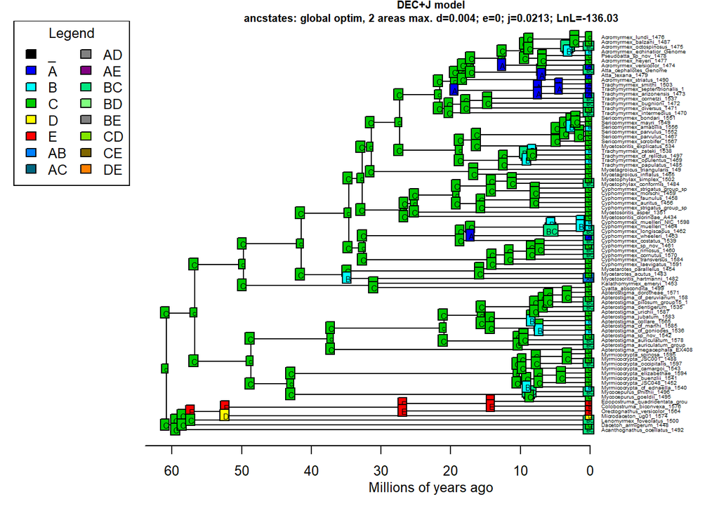

```
##         LnL nparams           d     e          j
## 1 -136.0288       3 0.004046294 1e-12 0.02133334
```

```r
layout(matrix(1:2, 1,2), widths=c(0.2,0.8))
par(mar=c(4.1,0.1,1.3,0.1),cex=0.8)
plot_BioGeoBEARS_results(DEC_J.fit,
      analysis_titletxt = "DEC+J model",
      plotlegend = TRUE, tipcex = 0.4,statecex = 0.4)
```

Notice that similar to the DEC model, the ancestral area for the group is hypothesized to be C (South America). However, hypothesized area reconstructions within the phylogeny do differ between the two models.

### **Model Comparison**

Because some details differ we may wish to formally perform a model comparison to deterimine which model confers the stronger statistical support.

```r
logL.DEC <- get_LnL_from_BioGeoBEARS_results_object(DEC.fit)
logL.DECJ <- get_LnL_from_BioGeoBEARS_results_object(DEC_J.fit)
AIC.table <- AICstats_2models(logL.DECJ,logL.DEC, numparams1 = 3,
                              numparams2 = 2)
print(AIC.table)
```

```
##   alt null            LnLalt           LnLnull DFalt DFnull DF       Dstatistic
## 1          -136.028802264747 -143.031334084131     3      2  1 14.0050636387663
##                   pval        test       tail     AIC1     AIC2    AICwt1
## 1 0.000182318980222173 chi-squared one-tailed 278.0576 290.0627 0.9975336
##        AICwt2 AICweight_ratio_model1 AICweight_ratio_model2
## 1 0.002466386               404.4515            0.002472484
```

Here we see that the DEC+J model has much stronger support than the DEC model. Thus, we reject DEC in favor of a model that also includes jump speciation.